# Problem 2:

a) What is the photon spectrum [1/keV/cm2/s] for a tungsten anode x-ray tube for a peak energy of 100 keV, 10 keV minimum energy, 30° anode angle at 1m (air) with a 2 mm aluminum filter and a current of 400 mA?  
b) Describe briefly the effect of increasing the aluminum filter thickness on the x-ray flux.  
c) Using the spectrum from a), calculate the spectrum averaged attenuation coefficient for steel (iron), aluminum and water.

Hint: Download “SpekCalc light” from spekcalc.weebly.com and use the NIST-library (https://physics.nist.gov).

- steel: density = 8.05 g/cm3; Standard atomic weight = 55.845 g/mol
- aluminum: density = 2.70 g/cm3; Standard atomic weight = 26.981 g/mol
- water: density = 0.998 g/cm3; Standard atomic weight = 18 g/mol

```python
import numpy as np
import pandas as pd
import matplotlib.pyplot as plt
import os, sys, glob
import re
import matplotlib
from matplotlib import pyplot as plt
from matplotlib.ticker import AutoMinorLocator
from scipy.integrate import simps
from scipy import interpolate
```

```python
os.environ["PATH"] += os.pathsep + '/usr/local/texlive/2018/bin/x86_64-darwin'
plt.rc('text', usetex=True)
plt.rc('font', weight='bold')
matplotlib.rcParams['mathtext.fontset'] = 'custom'
matplotlib.rcParams['mathtext.rm'] = 'Arial'
matplotlib.rcParams['mathtext.it'] = 'Arial:italic'
matplotlib.rcParams['mathtext.bf'] = 'Arial:bold'
matplotlib.rcParams['mathtext.tt'] = 'Arial'
matplotlib.rcParams['mathtext.cal'] = 'Arial'
matplotlib.rcParams['text.latex.preamble'] = [r'\usepackage{sfmath} \boldmath']
```

# a)

What is the photon spectrum [1/keV/cm2/s] for a tungsten anode x-ray tube for a peak energy of 100 keV, 10 keV minimum energy, 30° anode angle at 1m (air) with a 2 mm aluminum filter and a current of 400 mA?

### Use SpekCalc light (note that you need to change the filter thickness to 2 mm and e.g finer energy binning to 0.1 keV) obtain the following spectrum:

[figure not shown]

### Exporting the data from a) via “View Data” and importing into a software package (i.e. Matlab). Results as csv in “01_spectrum_raw.csv”.

```python
# SpekCalcFile with 0.1 kev energy binning
spek_file = './01_spectrum_raw.csv'

# import data
df_spek = pd.read_csv(spek_file, skiprows=1, index_col=0, header=None, delimiter=',')
df_spek.columns=['Energy_keV', 'phi_cm2_s_mA_keV']
df_spek.head()
```

| 0 | Energy_keV | phi_cm2_s_mA_keV |
| --- | --- | --- |
| 0 | 10.0 | 13.44400 |
| 1 | 10.1 | 18.10739 |
| 2 | 10.2 | 24.40184 |
| 3 | 10.3 | 32.94153 |
| 4 | 10.4 | 44.54384 |

### Multiply for each bin with the current of 400 mA to compute the spectrum in units of [1/keV/cm2/s]:

```python
# account for mA
tube_current = 400  # mA
df_spek['phi_cm2_s_keV'] = df_spek['phi_cm2_s_mA_keV'] * tube_current
df_spek.head()
```

| 0 | Energy_keV | phi_cm2_s_mA_keV | phi_cm2_s_keV |
| --- | --- | --- | --- |
| 0 | 10.0 | 13.44400 | 5377.600 |
| 1 | 10.1 | 18.10739 | 7242.956 |
| 2 | 10.2 | 24.40184 | 9760.736 |
| 3 | 10.3 | 32.94153 | 13176.612 |
| 4 | 10.4 | 44.54384 | 17817.536 |

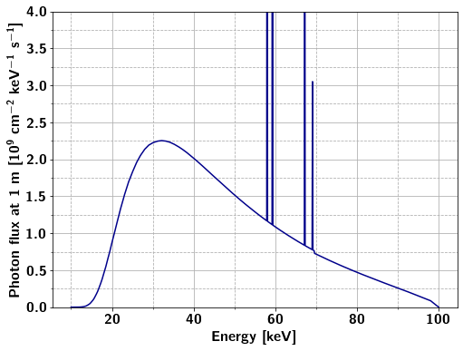

```python
fs = 16
fig, ax = plt.subplots(figsize=(8, 6))
plt.plot(df_spek['Energy_keV'].values, df_spek['phi_cm2_s_keV'].values/1e9, color='darkblue')
plt.ylabel(r'\textbf{Photon flux at 1 m [10$^9$ cm$^{-2}$ keV$^{-1}$ s$^{-1}$]}', fontsize=fs)
plt.xlabel(r'\textbf{Energy [keV]}', fontsize=fs)
plt.ylim(0, 4)

ax.tick_params(axis = 'both', which = 'major', labelsize = fs)
# minor ticks x
minor_locator = AutoMinorLocator(2)
ax.xaxis.set_minor_locator(minor_locator)
# minor ticks y
minor_locator = AutoMinorLocator(2)
ax.yaxis.set_minor_locator(minor_locator)
# grid
ax.grid(b=True, which='major', linestyle='-')#, color='gray')
ax.grid(b=True, which='minor', linestyle='--')#, color='gray')
plt.show()
plt.close()

df_spek[['Energy_keV', 'phi_cm2_s_keV']].to_csv('02_spectrum.csv', header=['Energy [keV]', 'Photon flux at 1 m [1/cm2/keV/s]'])
```

Spectrum is exported as "02_spectrum.csv".

# b)

Describe briefly the effect of increasing the aluminum filter thickness on the x-ray flux.

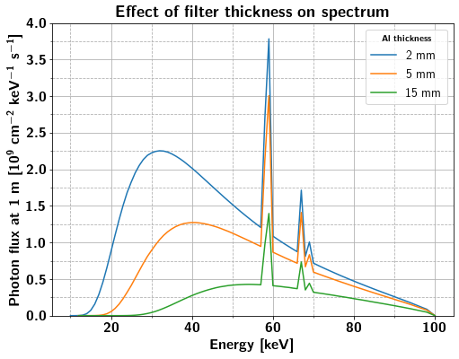

```python
files = ['spectrum_Al_2mm.txt', 'spectrum_Al_5mm.txt', 'spectrum_Al_15mm.txt']
lst_df = []
for file in files:
    al_thickness = re.findall(r'(\d*)mm', file)[0]
    # import data
    df = pd.read_csv(file, skiprows=2, header=None, delimiter='\s+')
    df.columns=['Energy_keV', 'phi_cm2_s_mA_keV']
    # account for mA
    tube_current = 400  # mA
    df['phi_cm2_s_keV'] = df['phi_cm2_s_mA_keV'] * tube_current
    df['label'] = f'{al_thickness} mm'
    lst_df.append(df)

fs = 16
plt.figure(figsize=(8, 6))
for df in lst_df:
    plt.plot(df['Energy_keV'], df['phi_cm2_s_keV'].values/1e9, label=df['label'].unique()[0])
plt.title(r'\textbf{Effect of filter thickness on spectrum}', fontsize=fs+2)
plt.ylabel(r'\textbf{Photon flux at 1 m [10$^9$ cm$^{-2}$ keV$^{-1}$ s$^{-1}$]}', fontsize=fs)
plt.xlabel(r'\textbf{Energy [keV]}', fontsize=fs)
plt.ylim(0, 4)
plt.legend(title=r'\textbf{Al thickness}', fontsize=fs-2)
ax = plt.gca()
ax.tick_params(axis = 'both', which = 'major', labelsize = fs)
ax.tick_params(axis = 'both', which = 'major', labelsize = fs)
# minor ticks x
minor_locator = AutoMinorLocator(2)
ax.xaxis.set_minor_locator(minor_locator)
# minor ticks y
minor_locator = AutoMinorLocator(2)
ax.yaxis.set_minor_locator(minor_locator)
# grid
ax.grid(b=True, which='major', linestyle='-')#, color='gray')
ax.grid(b=True, which='minor', linestyle='--')#, color='gray')
plt.show()
plt.close()
```

---> The spectrum gets harder with increasing filter thickness, but at the same time the total intensity also decreases. There is a tradeoff between hardness and total intensity.

# c)

Using the spectrum from a), calculate the spectrum averaged attenuation coefficient for steel (iron), aluminum and water.

---> Use the spectrum from a).

- Normalize the spectrum $\phi(E)$ to obtain a distribution function $\phi_{norm}(E)$:

$$\phi_{norm}(E) = \frac{\phi(E)}{\int_0^{\infty}\phi(E) dE}$$

- Check the normalization, so that $\int_0^{\infty}\phi_{norm}(E) dE = 1$

```python
# normalization by the area under the curve, energy binning is 0.1 keV!
X = df_spek['Energy_keV'].values
Y = df_spek['phi_cm2_s_keV'].values
area_tot = simps(Y, X)
# print(area_tot, X)
df_spek['phi_norm'] = df_spek['phi_cm2_s_keV']/area_tot

# check the normalization
Y = df_spek['phi_norm'].values
print(simps(Y, X))
df_spek.head()
```

```
1.0
```

| 0 | Energy_keV | phi_cm2_s_mA_keV | phi_cm2_s_keV | phi_norm |
| --- | --- | --- | --- | --- |
| 0 | 10.0 | 13.44400 | 5377.600 | 5.526965e-08 |
| 1 | 10.1 | 18.10739 | 7242.956 | 7.444132e-08 |
| 2 | 10.2 | 24.40184 | 9760.736 | 1.003184e-07 |
| 3 | 10.3 | 32.94153 | 13176.612 | 1.354260e-07 |
| 4 | 10.4 | 44.54384 | 17817.536 | 1.831243e-07 |

Spectrum averaged photon energy (not required):

$$<E> = \int_0^{\infty}E * \phi_{norm}(E) dE$$

```python
# switch energies to the center bin energy
df_spek['CenterBinEnergy_keV'] = df_spek['Energy_keV'] + 0.05

# compute E times intensity: <E> = int_0^inf(E * phi * dE)
df_spek['ExI'] = np.multiply(df_spek['CenterBinEnergy_keV'], df_spek['phi_norm'])
# average photon energy
E_avg = simps(df_spek['ExI'], df_spek['CenterBinEnergy_keV'] )
```

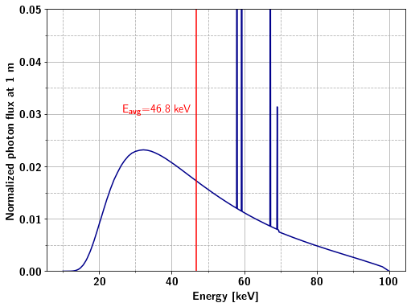

```python
fs = 14
plt.figure(figsize=(8, 6))
plt.plot(df_spek['Energy_keV'], df_spek['phi_norm'], color='darkblue')

plt.plot([E_avg, E_avg], [0, 0.05], color='red')
ax = plt.gca()
ax.text(26.5,0.03, r'E$_{avg}$' + r'={:.1f} keV'.format(E_avg), color='red', fontsize=fs)

plt.ylabel(r'\textbf{Normalized photon flux at 1 m}', fontsize=fs)
plt.xlabel(r'\textbf{Energy [keV]}', fontsize=fs)
plt.ylim(0, 0.05)

ax.tick_params(axis = 'both', which = 'major', labelsize = fs)
# minor ticks x
minor_locator = AutoMinorLocator(2)
ax.xaxis.set_minor_locator(minor_locator)
# minor ticks y
minor_locator = AutoMinorLocator(2)
ax.yaxis.set_minor_locator(minor_locator)
# grid
ax.grid(b=True, which='major', linestyle='-')#, color='gray')
ax.grid(b=True, which='minor', linestyle='--')#, color='gray')
plt.show()
plt.close()

df_spek[['Energy_keV', 'phi_norm']].to_csv('03_spectrum.csv', header=['Energy [keV]', 'Photon flux at 1 m [1/cm2/keV/s] (normalized)'])
```

Create an interpolation function using $Y=\phi_{norm}(E)$ and $X=E$ for energies between minimum and maximum photon energies ($E_{min}$ and $E_{max}$).

```python
# interpolate the flux
interpPhi_norm = interpolate.interp1d(df_spek['Energy_keV'].values, df_spek['phi_norm'].values, fill_value='extrapolate')

# minimum and maximum spectrum photon energy
E_max = np.max(df_spek['Energy_keV'])
E_min = np.min(df_spek['Energy_keV'])
```

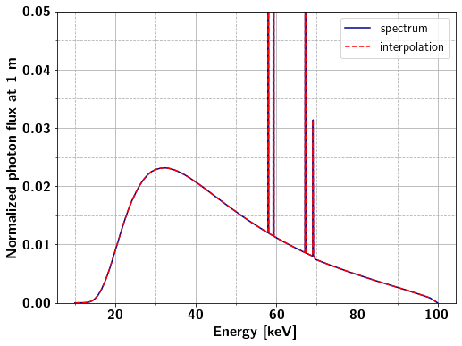

```python
fs = 16
E_vec = np.arange(E_min, E_max+0.1, 0.1)
plt.figure(figsize=(8, 6))
plt.plot(df_spek['Energy_keV'], df_spek['phi_norm'], color='darkblue', label='spectrum')
plt.plot(E_vec, interpPhi_norm(E_vec), color='red', linestyle='--', label='interpolation')


plt.ylabel(r'\textbf{Normalized photon flux at 1 m}', fontsize=fs)
plt.xlabel(r'\textbf{Energy [keV]}', fontsize=fs)
plt.ylim(0, 0.05)
plt.legend(fontsize=fs-2)
ax = plt.gca()
ax.tick_params(axis = 'both', which = 'major', labelsize = fs)
# minor ticks x
minor_locator = AutoMinorLocator(2)
ax.xaxis.set_minor_locator(minor_locator)
# minor ticks y
minor_locator = AutoMinorLocator(2)
ax.yaxis.set_minor_locator(minor_locator)
# grid
ax.grid(b=True, which='major', linestyle='-')#, color='gray')
ax.grid(b=True, which='minor', linestyle='--')#, color='gray')
plt.show()
plt.close()
```

Import the X-Ray Mass Attenuation Coefficients for iron and aluminum from https://physics.nist.gov/PhysRefData/XrayMassCoef/tab3.html (As an alternative, one can use https://physics.nist.gov/PhysRefData/Xcom/html/xcom1.html)

[figure not shown]

Import the X-Ray Mass Attenuation Coefficients for water from https://physics.nist.gov/PhysRefData/XrayMassCoef/tab4.html

[figure not shown]

Using the densities for the respective material (given in the exercise or use the values in the NIST tables https://physics.nist.gov/PhysRefData/XrayMassCoef/tab1.html and https://physics.nist.gov/PhysRefData/XrayMassCoef/tab2.html) to compute the attenuation coefficient for each of the energies in the table:

$$\mu = \frac{\mu}{\rho} * \rho$$

Convert the energies from MeV into keV.

Interpolate the attenuation coefficient and resample in smaller energy steps (i.e. 0.1 keV). Should be the same as the SpekCalc-data. If the alternative attenuation coefficient website is used, this is not necessary as the energies requested can be put in manually.

Results for the attenuation coefficients are in “04_attenuation_coefficient_XXX.csv”, where XXX is the material.

The spectrum averaged attenuation coefficient is: $$\mu_{avg} = \int_0^{\infty} \mu(E) * \phi_{norm}(E) dE$$

Numerical integration (Simpson’s rule or trapezoidal rule) yields:  
47.39 1/cm for steel,  
2.35 1/cm for aluminum and  
0.32 1/cm for water.

Note, a more general formula for the spectrum averaged attenuation coefficient is: $$\mu_{avg} = \frac{\int_0^{\infty} \mu(E) * \phi(E) dE}{\int_0^{\infty} \phi(E) dE}$$

```
mu_avg for steel is 47.40 1/cm
mu_avg for alu is 2.35 1/cm
mu_avg for water is 0.32 1/cm
```

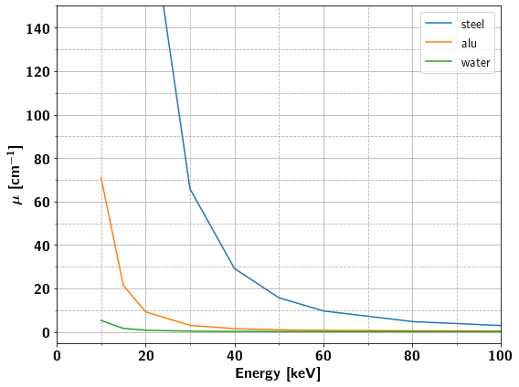

```python
# -------------------------------------------------------------------
# NIST
# -------------------------------------------------------------------
# energy in MeV, mass att coeff in cm2/g, some other value
material = ['steel', 'alu', 'water']

# densities for steel, alu, water
rhos = [8.05, 2.70, 0.998] # g/cm3

lst_df_NIST = []
ii = 0
for mat in material:
	# read file
	df_t = pd.read_csv('NIST_' + mat, delimiter='\s+', header = None)
	# rename columns
	df_t.columns = ['energy_MeV', 'mass_att_coeff', 'x']
	# convert to keV
	df_t['energy_keV'] = np.multiply(df_t['energy_MeV'], 1e3)
	# calculate attenuation coefficient 1/cm
	df_t['mu_1_p_cm'] = np.multiply(df_t['mass_att_coeff'], rhos[ii])

	# interpolate the attenuation coefficient
	interpNu = interpolate.interp1d(df_t['energy_keV'].values, df_t['mu_1_p_cm'].values, fill_value='extrapolate')
	# energies for the attenuation coefficient
	energies = np.arange(E_min, E_max+0.1, 0.1)

	# output DF
	df_out = pd.DataFrame(columns=['energy_keV', 'nu_1_p_cm', 'phi_norm'])
	df_out['energy_keV'] = energies
	df_out['mu_1_p_cm'] = interpNu(energies)
	df_out['phi_norm'] = interpPhi_norm(energies)
	df_out['mu_x_phi_norm'] = np.multiply(df_out['mu_1_p_cm'], df_out['phi_norm'])

	mu_avg = simps(df_out['mu_x_phi_norm'], df_out['energy_keV'])

	print(r'mu_avg for {} is {:.2f} 1/cm'.format(mat, mu_avg))

	ii = ii + 1


	lst_df_NIST.append(df_out)


# -------------------------------------------------------------------
# plot mu
# -------------------------------------------------------------------
plt.rc('text', usetex=True)
plt.rc('font', weight='bold')
matplotlib.rcParams['mathtext.fontset'] = 'custom'
matplotlib.rcParams['mathtext.rm'] = 'Arial'
matplotlib.rcParams['mathtext.it'] = 'Arial:italic'
matplotlib.rcParams['mathtext.bf'] = 'Arial:bold'
matplotlib.rcParams['mathtext.tt'] = 'Arial'
matplotlib.rcParams['mathtext.cal'] = 'Arial'
matplotlib.rcParams['text.latex.preamble'] = [r'\usepackage{sfmath} \boldmath']

fig = plt.figure(figsize=(8,6))

####################
# axis 1
####################
ax1 = fig.add_subplot(1, 1, 1)

# plot
ii = 0
for this_df in lst_df_NIST:
	ax1.plot(this_df['energy_keV'], this_df['mu_1_p_cm'], label=material[ii])
	ii = ii + 1
# ax1.plot([E_avg,E_avg], [0,0.1], color='red')
# ax1.text(24.5,0.0005, r'E$_{avg}$' + r'={:.1f} keV'.format(E_avg), color='red')
ax1.tick_params('x', colors='black', labelsize=fs)
ax1.tick_params('y', colors='black', labelsize=fs)
# grid
ax1.set_xlabel(r'\textbf{Energy [keV]}', fontsize=fs)
ax1.set_ylabel(r'\textbf{$\mu$ [cm$^{-1}$]}', fontsize=fs)

ylims = ax1.get_ylim()
ax1.set_ylim(-5, 150)
ax1.set_xlim(0, 100)

# minor ticks x
minor_locator = AutoMinorLocator(2)
ax1.xaxis.set_minor_locator(minor_locator)
# minor ticks y
minor_locator = AutoMinorLocator(2)
ax1.yaxis.set_minor_locator(minor_locator)
# grid
ax1.grid(b=True, which='major', linestyle='-')#, color='gray')
ax1.grid(b=True, which='minor', linestyle='--')#, color='gray')
# fig.subplots_adjust(left=0.15, right=0.97, top=0.88, bottom=0.18)
plt.legend(loc='best', fontsize=fs-2)
plt.tight_layout()
plt.savefig('./mu_vs_energy.png', dpi=600)

plt.show()
```